# Xeva Tutorial

This hands-on activity focuses on analysis of patient-derived xenograft (PDX) based pharmacogenomic data. We will learn about PDX based drug screening and biomarker discovery. Using the R package `Xeva` we will visualise the PDX data. We will also perform univariate biomarker discovery in the PDX data.

# Installation and Settings

[Xeva](https://bioconductor.org/packages/3.9/bioc/html/Xeva.html) requires that several packages be installed. All dependencies are available from CRAN or Bioconductor:

```r
if (!requireNamespace("BiocManager", quietly = TRUE))
    install.packages("BiocManager")
BiocManager::install("Xeva")
```

Alternatively, the packgae can be installed for [Github](https://github.com/bhklab/Xeva):

```r
library(devtools)
devtools::install_github("bhklab/Xeva")
```

Load Xeva into your current workspace:

```r
library(Biobase)
library(Xeva)
```

# Data Access

Now we load the dataset for the analysis. For the sake of this tutorial, here we load the Novartis PDXE breast cancer dataset as an example:

```r
data(brca)
print(brca)
```

[output not shown]

Xeva stores metadata for each individual PDX model. We can retrieve the meta-information about each PDX, such as number of models and tissue type, using:

```r
brca.mod <- modelInfo(brca)
dim(brca.mod)
```

```
## [1] 849   5
```

```r
brca.mod[1:4, ]
```

|  | model.id | tissue | tissue.name | patient.id | drug |
| --- | --- | --- | --- | --- | --- |
| X.1004.BG98 | X.1004.BG98 | BRCA | Breast Cancer | X-1004 | BGJ398 |
| X.1004.biib | X.1004.biib | BRCA | Breast Cancer | X-1004 | binimetinib |
| X.1004.BK20 | X.1004.BK20 | BRCA | Breast Cancer | X-1004 | BKM120 |
| X.1004.BY19 | X.1004.BY19 | BRCA | Breast Cancer | X-1004 | BYL719 |

The output shows that the `brca` dataset contains 849 PDX models. We can also see the time vs. tumor volume data for a model using:

```r
model.data <- getExperiment(brca, model.id = "X.1004.BG98")
head(model.data)
```

|  | model.id | drug.join.name | time | volume | body.weight | volume.normal |
| --- | --- | --- | --- | --- | --- | --- |
| 1 | X.1004.BG98 | BGJ398 | 0 | 199.7 | 28.2 | 0.0000000 |
| 2 | X.1004.BG98 | BGJ398 | 2 | 181.9 | 28.0 | -0.0891337 |
| 3 | X.1004.BG98 | BGJ398 | 5 | 172.7 | 28.4 | -0.1352028 |
| 4 | X.1004.BG98 | BGJ398 | 9 | 129.6 | 27.2 | -0.3510265 |
| 5 | X.1004.BG98 | BGJ398 | 12 | 91.3 | 26.7 | -0.5428142 |
| 6 | X.1004.BG98 | BGJ398 | 16 | 117.1 | 26.2 | -0.4136204 |

Similarly, for **batch** names, we can obtain all predefined batch names using:

```r
batch.name <- batchInfo(brca)
batch.name[1:4]
```

```
## [1] "X-1004.BGJ398"      "X-1004.binimetinib" "X-1004.BKM120"
## [4] "X-1004.BYL719"
```

The information about a **batch** can be shown using:

```r
batchInfo(brca, batch = "X-1004.binimetinib")
```

```
## $`X-1004.binimetinib`
## name = X-1004.binimetinib
## control = X.1004.uned
## treatment = X.1004.biib
```

Here, for the batch named `X-1004.binimetinib`, we can see that the control sample is `X.1004.uned` and the treatment sample is `X.1004.biib`.

# Visualizing PDX Growth Curve

Xeva provides a function to plot time vs. tumor volume data for individual models as well as for individual batches. These data can be plotted by using the name of the batch:

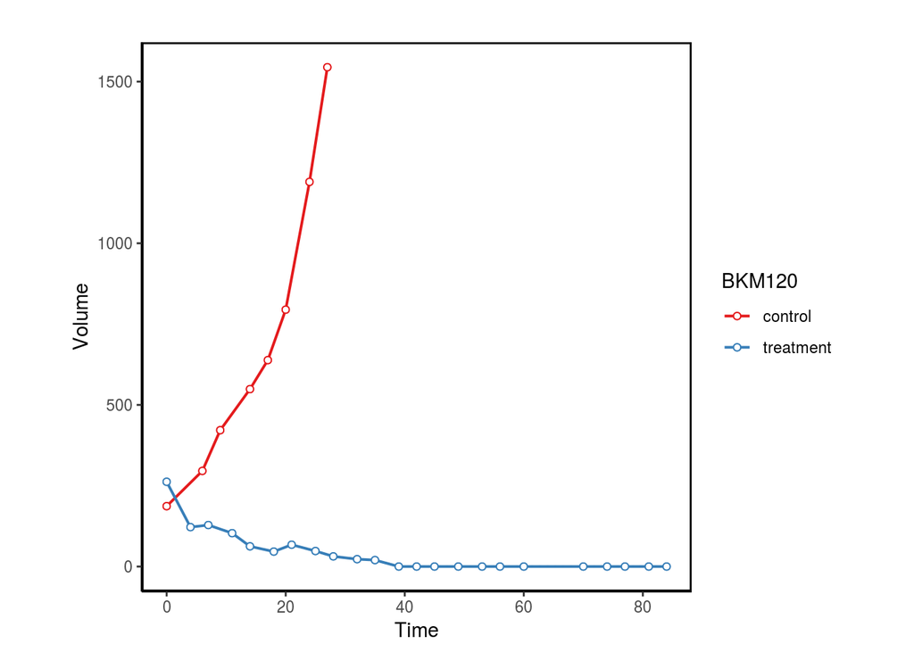

Tumor growth curves for a batch of control and treated PDXs

```r
print(plotPDX(brca, batch = "X-4567.BKM120"))
```

You can choose to see different aspects of this visualization. For example, we can plot normalized volume; we can also change the colors of the lines:

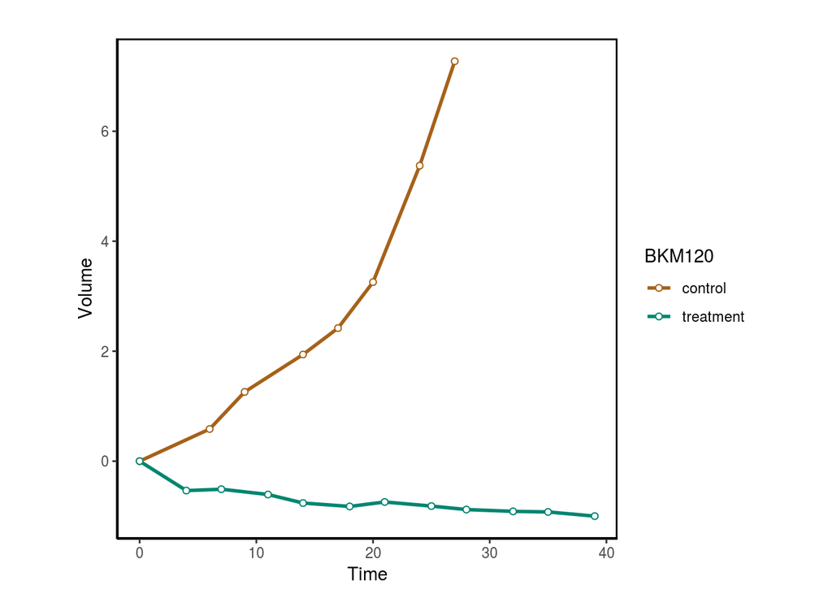

Tumor growth curves for a batch of control and treated PDXs. Here, the volume is normalized and plots are truncated at 40 days

```r
plotPDX(brca, batch = "X-4567.BKM120", vol.normal = TRUE, control.col = "#a6611a",
        treatment.col = "#018571", major.line.size = 1, max.time = 40)
```

Data can also be visualized at the patient level by specifying *patient.id*:

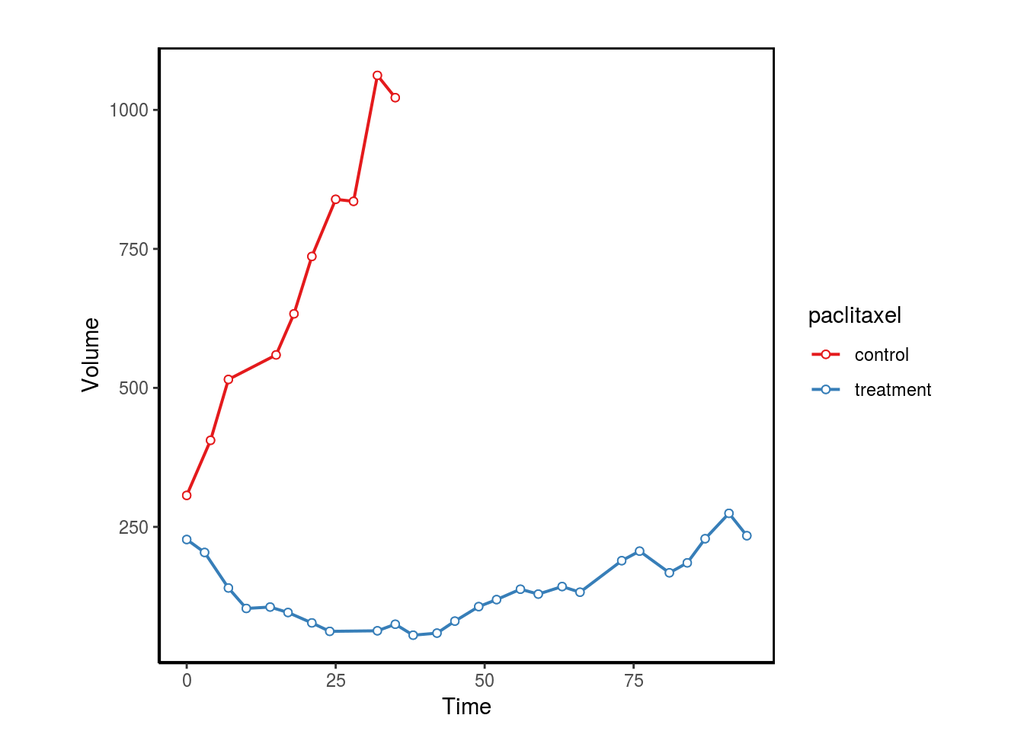

Tumor growth curves for a batch of control and treated PDXs generated using patient ID and drug name

```r
plotPDX(brca, patient.id="X-3078", drug="paclitaxel",control.name = "untreated")
```

# Replicate-based PDX experiments

Xeva can also handle replicate-based experiment design. The datasets included in the package also contain replicate-based PDX experiments. To plot replicate-based data:

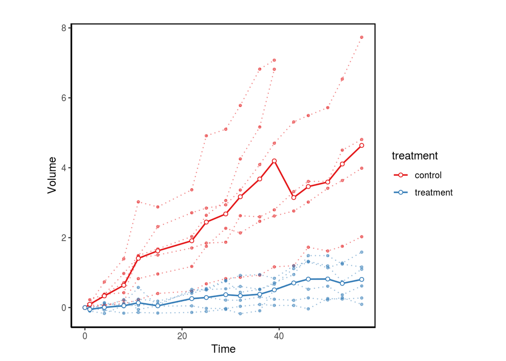

Tumor growth curves for a batch of control and treated PDXs with replicates

```r
data("repdx")
plotPDX(repdx, vol.normal = TRUE, batch = "P1")
```

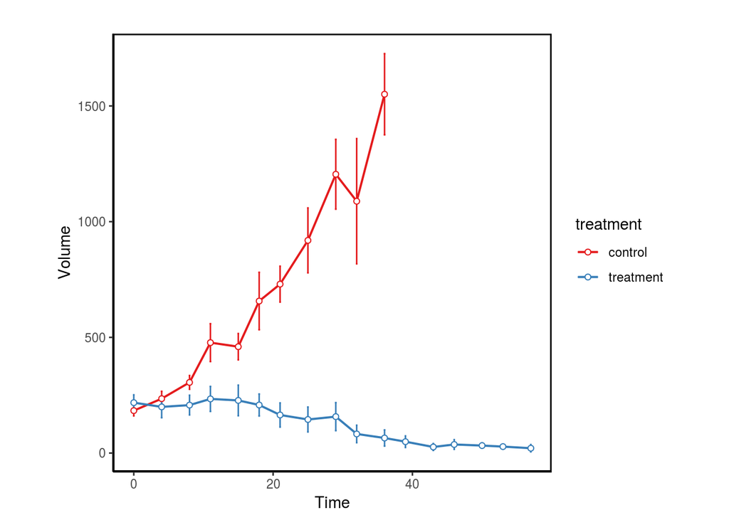

Errorbar visualization for tumor growth curves of a PDX batch

```r
plotPDX(repdx, batch = "P3", SE.plot = "errorbar")
```

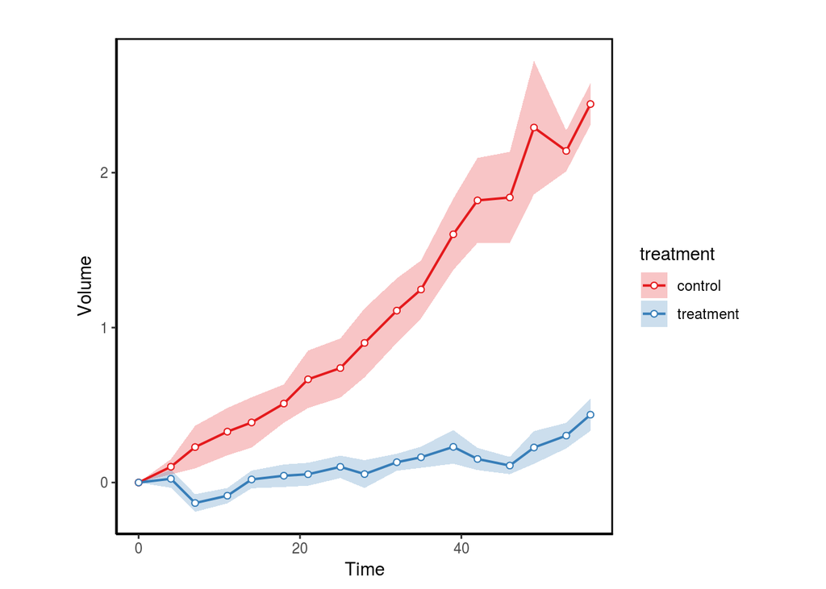

Ribbon visualization for tumor growth curves of a PDX batch

```r
plotPDX(repdx, batch = "P4", vol.normal = TRUE,  SE.plot = "ribbon")
```

# PDX Model Drug Response

Xeva can effectively summarize PDX drug response data. Here we summarize the **mRECIST} values for the models in our dataset:

```r
brca.mr <- summarizeResponse(brca, response.measure = "mRECIST")
brca.mr[1:5, 1:4]
```

|  | X-1004 | X-1008 | X-1286 | X-1298 |
| --- | --- | --- | --- | --- |
| BGJ398 | PR | SD | PD | SD |
| binimetinib | PD | SD | SD | PD |
| BKM120 | SD | SD | SD | PR |
| BYL719 | SD | PR | SD | PD |
| BYL719 + LEE011 | PD | SD | SD | PD |

These **mRECIST** values can be visualized using:

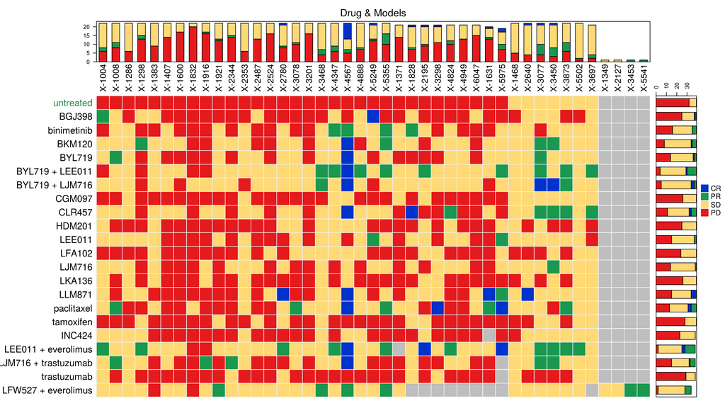

mRECIST plot for PDXE breast cancer data

```r
plotmRECIST(brca.mr, control.name="untreated", row_fontsize=13, col_fontsize=12)
```

Waterfall plots are also commonly used to visualize PDX drug response data. Xeva provides a function to visualize and color waterfall plots:

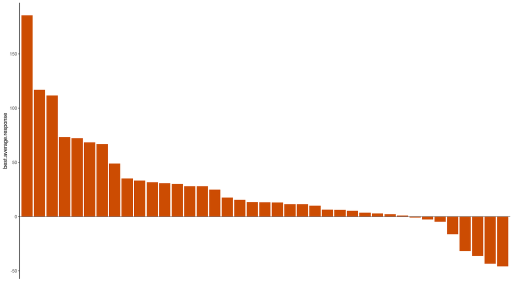

Waterfall plot for binimetinib drug response in PDXs

```r
waterfall(brca, drug="binimetinib", res.measure="best.average.response")
```

It is useful to color the bars of your waterfall plot by genomic properties. Here we create a waterfall plot for drug BYL719 and color it based on the mutation status of the CDK13 gene. First, we extract the genomic data for the models. Then, we can plot the waterfall plots:

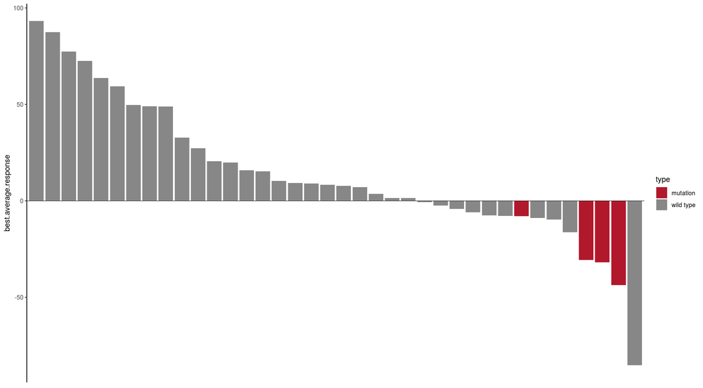

Waterfall plot for BYL719 drug response in PDXs

```r
mut <- summarizeMolecularProfiles(brca,drug = "BYL719", mDataType="mutation")
model.type <- Biobase::exprs(mut)["CDK13", ]
model.type[grepl("Mut", model.type)] <- "mutation"
model.type[model.type!="mutation"] <- "wild type"
model.color <- list("mutation"="#b2182b", "wild type"="#878787")
waterfall(brca, drug="BYL719", res.measure="best.average.response",
          model.id=names(model.type), model.type= model.type,
          type.color = model.color)
```

In Xeva we have implemented difference matrix to compute PDX response. The Xeva function **response** provides a unified interface for this purpose. In the example below we compute the angle between treatment and control PDXs

```r
data("repdx")
Xeva::response(repdx, batch="P1", res.measure="angle")
```

```
## computing angle for batch P1
```

```
## angle = 18.665650
## control = 85.751806
## treatment = 67.086156
```

# Gene-drug association

The main aim of the pharmacogenomic experiments is to find biomarkers for drug response prediction. The Xeva package provides the **drugSensitivitySig** function to compute the univariate association between PDX’s molecular data (such as gene expression) and response to a drug (gene-drug association). In the example bellow, we are computing the association between gene expression (RNASeq) and slope of the PDXs for the drug `tamoxifen` using linear regression (lm).

```r
data(brca)
Xeva::drugSensitivitySig(object=brca, drug="tamoxifen", mDataType="RNASeq",
                   features=c(1,2,3,4,5), sensitivity.measure="slope", fit="lm")
```

```
## Running for drug tamoxifen
```

| feature | drug | estimate | se | n | tstat | fstat | pvalue | df | fdr |
| --- | --- | --- | --- | --- | --- | --- | --- | --- | --- |
| PIK3R6 | tamoxifen | 0.12174756 | 0.1654268 | 38 | 0.73596007 | 0.541637222 | 0.4665236 | 36 | 0.7775393 |
| FGFR1 | tamoxifen | -0.16019355 | 0.1645143 | 38 | -0.97373653 | 0.948162830 | 0.3366852 | 36 | 0.7775393 |
| NTRK2 | tamoxifen | 0.16560706 | 0.1643653 | 38 | 1.00755487 | 1.015166810 | 0.3203927 | 36 | 0.7775393 |
| AKT1 | tamoxifen | 0.00996873 | 0.1666584 | 38 | 0.05981535 | 0.003577876 | 0.9526335 | 36 | 0.9526335 |
| FGFR4 | tamoxifen | 0.07953256 | 0.1661387 | 38 | 0.47871178 | 0.229164971 | 0.6350385 | 36 | 0.7937981 |

In this above example we took only 5 features (genes), however this can be extended for any number of genes. For larger analyses, this function also provides out of box parallel computation.

Users can choose different sensitivity measures of the PDX response for the association analysis by setting the parameter **sensitivity.measure**. For example, below we use *best.average.response* as the PDX’s response matrix in the association analysis:

```r
data(brca)
Xeva::drugSensitivitySig(object=brca, drug="tamoxifen", mDataType="RNASeq",
                   features=c(1,2,3,4,5),
                   sensitivity.measure="best.average.response", fit = "lm")
```

```
## Running for drug tamoxifen
```

| feature | drug | estimate | se | n | tstat | fstat | pvalue | df | fdr |
| --- | --- | --- | --- | --- | --- | --- | --- | --- | --- |
| PIK3R6 | tamoxifen | 0.10155551 | 0.1658050 | 38 | 0.6124998 | 0.3751559 | 0.5440570 | 36 | 0.6800713 |
| FGFR1 | tamoxifen | 0.25347267 | 0.1612238 | 38 | 1.5721794 | 2.4717480 | 0.1246577 | 36 | 0.5882184 |
| NTRK2 | tamoxifen | 0.15268488 | 0.1647125 | 38 | 0.9269782 | 0.8592885 | 0.3601112 | 36 | 0.6001853 |
| AKT1 | tamoxifen | -0.19722241 | 0.1633931 | 38 | -1.2070422 | 1.4569510 | 0.2352874 | 36 | 0.5882184 |
| FGFR4 | tamoxifen | -0.06903067 | 0.1662691 | 38 | -0.4151744 | 0.1723698 | 0.6804783 | 36 | 0.6804783 |

For the drug-gene association analysis, users can also choose a different method of association calculation (such as concordance index, Pearson or Spearman correlation) by setting the parameter *fit*.

```r
data(brca)
Xeva::drugSensitivitySig(object=brca, drug="tamoxifen", mDataType="RNASeq",
                   features=c(1,2,3,4,5),
                   sensitivity.measure="best.average.response", fit="spearman")
```

```
## Running for drug tamoxifen
```

| feature | drug | cor | p.value |
| --- | --- | --- | --- |
| PIK3R6 | tamoxifen | 0.13296193 | 0.4261511 |
| FGFR1 | tamoxifen | 0.16971222 | 0.3071529 |
| NTRK2 | tamoxifen | 0.06210639 | 0.7110708 |
| AKT1 | tamoxifen | -0.23799103 | 0.1498528 |
| FGFR4 | tamoxifen | -0.02812124 | 0.8667552 |